# DSCI301 HW 5

Randy Nuhfer

9/19/2020

## Library loading…

```r
library(here)
library(tidyverse)
```

## Problem 1:

```r
Spotify_path <- here("datasets_1833_3172_data.csv")
Spotify <- read_csv(Spotify_path,
                    col_types = cols(
  X1 = col_double(),
  acousticness = col_double(),
  danceability = col_double(),
  duration_ms = col_double(),
  energy = col_double(),
  instrumentalness = col_double(),
  key = col_factor(),
  liveness = col_double(),
  loudness = col_double(),
  mode = col_factor(),
  speechiness = col_double(),
  tempo = col_double(),
  time_signature = col_double(),
  valence = col_double(),
  target = col_factor(),
  song_title = col_character(),
  artist = col_character()
))
```

After reading in the data I changed three columns. Firstly, I changed the key column to a factor column because there is only a set number of keys. Secondly, I also changed mode to a factor as it only indicates whether the song is in a major key or minor key. Finally I chnaged the target column to a factor as well as this only indicates whether or not the creator of this data set liked that particular song.

## Problem 2:

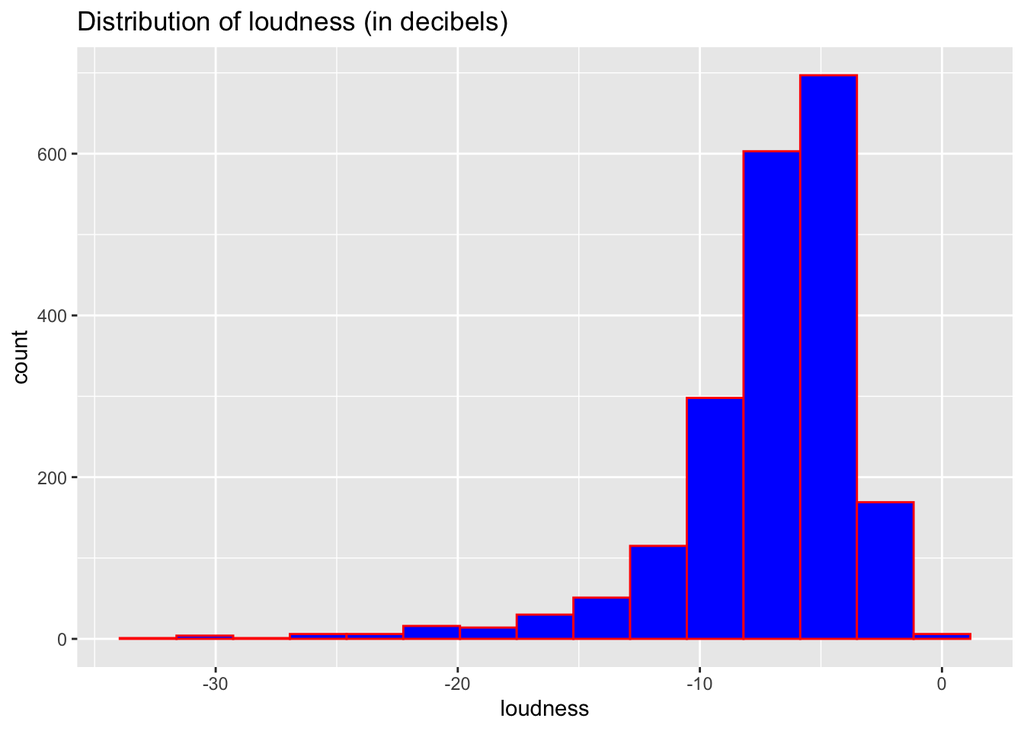

```r
Spotify %>%
    ggplot(aes(x = loudness)) +
    geom_histogram(bins = 15, fill = "blue", color = "red") +
    labs(title = "Distribution of loudness (in decibels)")
```

Looking at this graph we can clearly see most songs have a loundness around -5 decibels.

Hm. I had to go look up why these were reporting as negative decibels. (That seems like an immediate question on seeing this data!)

There is a bit more we could say here. Although there is a lot in the range of about -6 to -3, this is a left-skewed distribution; there are a lot of trailing values on the low end.

Also, that red border on the blue fill really clashes–I’d select something else.

## Problem 3:

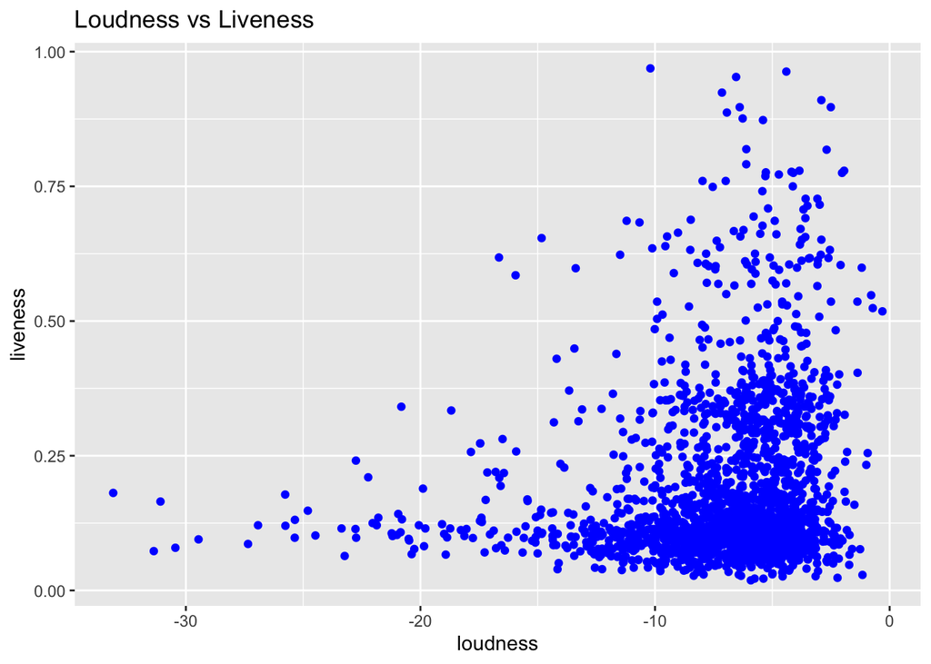

```r
Spotify %>%
    ggplot(aes(x = loudness, y = liveness)) +
    geom_point(color = "blue") +
    labs(title = "Loudness vs Liveness")
```

I think there is also some significant overplotting going on in the lower right corner. That is, I think there is a really high number of points there, which we can’t really see because they are plotting over each other. Adding an alpha (transparency) value (or using smaller points) might help the graph be more clear here:

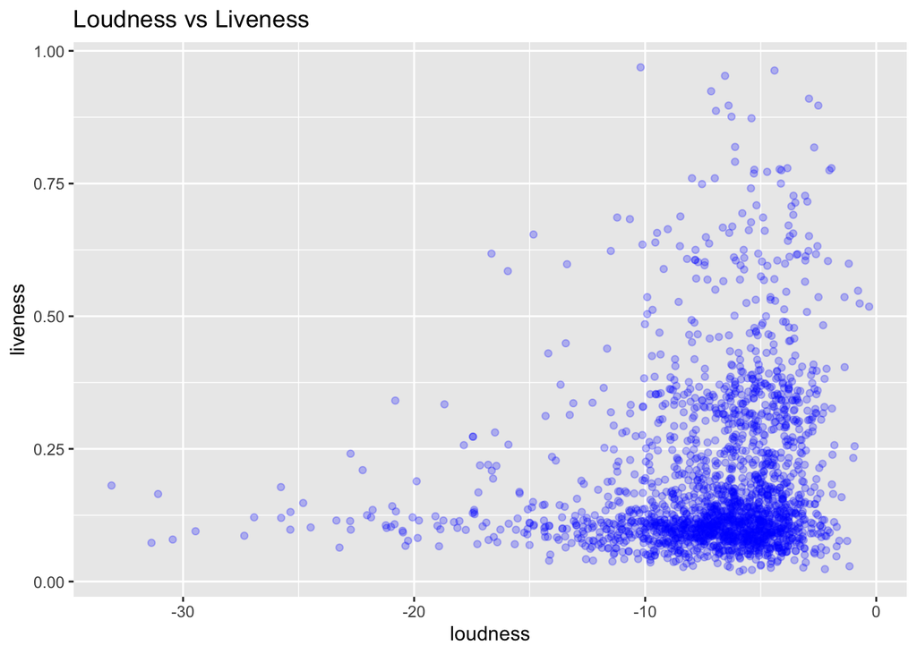

```r
Spotify %>%
    ggplot(aes(x = loudness, y = liveness)) +
    geom_point(color = "blue", alpha = .25) +
    labs(title = "Loudness vs Liveness")
```